## Statistics 523

### Assignment 3: One-Way S3 Package

#### Doug Raffle (dcraffle@mix.wvu.edu)

The file created from `R CMD build` (or similar approaches using `devtools` or RStudio shortcuts) should be submitted along with this file and its pdf output. I should be able to install the package—perhaps from GitHub.

**Extra credit of up to 10 points**: Use `git` for version control and publish your results on GitHub. If GitHub is used, the link should be provided.

Github source: github.com/raffled/oneway

#### 1. Start development of a package called `oneway` using the RStudio approach, i.e., start with a project. This initial version should be derived from your S3 classes developed for assignment 4 in the file `oneway.R` or similar files.

```r
#' Perform a oneway analysis of variance
#'
#' @param z A list of responses grouped by factor level
#' @param ... Addition arguments used by other S3 methods
#'
#' @seealso \code{\link{oneway.factor}}, \code{\link{oneway.formula}},
#' \code{\link{summary.oneway}}, \code{\link{plot.oneway}}, \code{\link{lsmeans}}
#' @examples
#' data(coagulation)
#' attach(coagulation)
#' oneway(split(coag, diet))
#' oneway(diet, coag)
#' oneway(coag~diet)
#' summary(oneway(coag~diet))
#'
#' lsmeans(oneway(coag~diet))
#' plot(oneway(coag~diet))
#'
#' @export
oneway <- function(z, ...) UseMethod("oneway")

#' @export
oneway.default <- function(z, ...) {
    ## Make sure we're the right data structure
    if(!is.list(z) | is.data.frame(z)){
        stop("data structure is not one of:\nlist, factor & vector, or formula")
    }
    ## computing formulas
    a <- length(z)
    N <- length(unlist(z))
    TT <- sum(unlist(z)^2)
    A <- sum(sapply(z, function(x) sum(x)^2/length(x)))
    CF <- sum(unlist(z))^2/N
    ## computes SS's and DF's
    ss.a <- A - CF ## within
    ss.e <- TT - A ## between
    df.a <- a - 1
    df.e <- N - a
    ## get LS Means & sample sizes
    ybar.vec <- unlist(lapply(z, mean))
    n.vec <- unlist(lapply(z, length))
    ## find group names
    if(is.null(names(z))){
        groups <- as.character(1:length(z))
    }
    else{
        groups <- names(z)
    }
    names(ybar.vec) <- groups
    ## create object, add class, & return
    res <- list(df = c(df.a, df.e), SS = c(ss.a, ss.e),
                groups = groups, call = match.call(), data = z,
                ls.means = ybar.vec, n.vec = n.vec, N = N, a = a)
    class(res) <- "oneway"
    return(res)
}

#' oneway.factor
#'
#' S3 method for \code{\link{oneway}} using a response vector and factor
#'
#' @param z A factor of levels for each observation
#' @param y A vector of responses
#' @param ... Addition arguments used by other S3 methods
#'
#' @seealso \code{link{oneway}}
#'
#' @export
oneway.factor <- function(z, y, ...) {
    foo <- oneway.default(split(y, z))
    foo$call <- match.call()
    foo
}

#' oneway.formula
#'
#' An S3 method for \code{\link{oneway}} for formulas.
#'
#' @param formula A formula of the form \code{response~factor}
#' @param data An (optional) data frame used by the formula.
#' @param ... Addition arguments used by other S3 methods
#'
#' @seealso \code{\link{oneway}}
#'
#' @export
oneway.formula <- function(formula, data=list(), ...) {
    mf <- model.frame(formula, data)
    foo <- oneway.factor(mf[,2], mf[,1])
    foo$call <- match.call()
    foo
}

#' @export
print.oneway <- function(x, ...) {
   print(x$call)
   cat("\nWithin SS:", x$SS[1], "on", x$df[1],
       "degrees of freedom.\n")
   cat("Between SS:", x$SS[2], "on", x$df[2],
       "degrees of freedom.\n")
}


#' summary.oneway
#'
#' Creates an Analysis of Variance table for a \code{oneway} object
#'
#' @param object An object of class \code{oneway}
#' @param ... Addition arguments used by other S3 methods
#'
#' @export
summary.oneway <- function(object, ...) {
    attach(object)
    ## Get total SS & df
    ss.t <- SS[1] + SS[2]
    df.t <- df[1] + df[2]
    ## Calculate mean squares
    ms.a <- SS[1]/df[1]
    ms.e <- SS[2]/df[2]
    ## get F stat & p-val
    F <- ms.a/ms.e
    p <- pf(F, df[1], df[2], lower.tail = FALSE)

    ## construct AOV table
    tab <- with(object, cbind(DF = c(df, df.t),
                         SS = c(SS, ss.t),
                         MS = c(ms.a, ms.e, NA),
                         F = c(F, NA, NA),
                         "Pr(>F)" = c(p, NA, NA)))
    rownames(tab) <- c("Among Groups", "Within Groups (error)",
                       "Total")
    res <- list(call=call, tab=tab, groups=groups, ls.means=ls.means,
                P = p, MS = c(ms.a, ms.e), n.vec = n.vec, N = N, a = a)
    class(res) <- "summary.oneway"
    detach(object)
    return(res)
}

#' @export
print.summary.oneway <- function(x, ...) {
    ## function call
    cat("Call:\n\t")
    print(x$call)
    ## LS means
    cat("\nMeans:\n")
    print(x$ls.means)
    cat("\n")
    # AOV Table
    cat("\nAnalysis of Variance Table:\n")
    printCoefmat(x$tab, P.values=TRUE, has.Pvalue=TRUE,
                 signif.stars=TRUE, na.print="")
}

#' Creates a side-by-side boxplot of groups in a \code{oneway} object
#'
#' @param x A \code{oneway} object
#' @param xlab X label of graph
#' @param ylab Y label of graph
#' @param main Main plot title
#' @param ... Optional graphing arguments to be passed to
#' \code{boxplot}
#'@param names Names of factor levels
#' @seealso \code{link{boxplot}}
#'
#' @export
plot.oneway <- function(x, names=x$groups, xlab="Group", ylab="Response",
                        main=capture.output(x$call), ...){
    boxplot(x=x$data, names=names, xlab=xlab, ylab=ylab, main=main, ...)
}

#' Perform Fisher's LSD
#'
#' Test pairwise differences using Fisher's LSD proceduce on a
#' \code{oneway} object
#'
#' @param object A \code{oneway} object
#'
#' @export
lsmeans <- function(object) UseMethod("lsmeans")

#' @export
lsmeans.default <- function(object){
    if(!(class(object)=="oneway")){
        stop("lsmeans only accepts class \"oneway\"")
    }
}

#' @export
lsmeans.oneway <- function(object) {
    object <- summary(object)
    if(object$P > 0.05){
        warning("F-test is not significant at alpha=0.05.")
    }
    compare <- function(i, j){
        d <- object$ls.means[i] - object$ls.means[j]
        s.e <- sqrt(object$MS[2]*(1/object$n.vec[i] + 1/object$n.vec[j]))
        t.val <- d/s.e
        round(2*pt(abs(t.val), object$N-object$a, lower.tail=FALSE),4)
    }
    p.vals <- pairwise.table(compare.levels=compare,
                             level.names=object$groups,
                             p.adjust.method="none")
    result <- list(p.value=p.vals, call=match.call())
    class(result) <- "lsmeans"
    result
}

#' @export
print.lsmeans <- function(x, ...){
    cat("Call:\n\t")
    print(x$call)
    cat("\nFisher's LSD Table\n")
    cat("\nP-Values:\n")
    print.table(x$p.value, na.print="-")
}
```

#### 2. Edit the DESCRIPTION file.

```
Package: oneway
Type: Package
Title: Oneway Analysis of Variance
Version: 0.1
Date: 2015-08-02
Author: Doug Raffle
Maintainer: Doug Raffle <dcraffle@mix.wvu.edu>
Description: Performs a oneway analysis of variance given: a named list of samples, a vector of responses and a factor with the group labels, or a formula.
License: GPL-3
LazyData: TRUE
```

#### 3. Generate a NAMESPACE file using `roxygen2`. That is, export (or less likely import) appropriate functions or S3 methods.

```
# Generated by roxygen2 (4.1.1): do not edit by hand

S3method(lsmeans,default)
S3method(lsmeans,oneway)
S3method(oneway,default)
S3method(oneway,factor)
S3method(oneway,formula)
S3method(plot,oneway)
S3method(print,lsmeans)
S3method(print,oneway)
S3method(print,summary.oneway)
S3method(summary,oneway)
export(lsmeans)
export(oneway)
```

#### 4. Develop a help file called `oneway.Rd`, or similar files, which contains the help information for all the functions defined in `oneway.R`, or in similar files. The help file(s) should be placed in a subdirectory called `man`. You should use `roxygen2` for this process.

#### 5. Create an image file from the `coagulation` data set using `save()` and place `coagulation.rda` in the subdirectory `data`.

```r
library(faraway)
data(coagulation)
save(coagulation, file = "./data/coagulation.rda")
```

#### 6. Develop a help file called `coagulation.Rd`, which contains the help information for the `coagulation` data set. This file should be placed in the `man` subdirectory. Again use `roxygen2`.

#### 7. Build the package using the `R CMD build` and the `R CMD check` commands or by RStudio commands or `devtools`. The process should be iterated until bugs are found and corrected. You can use the debugging tools you have learned. Once complete, install the package.

#### 8. Show the output from the help files using: `library(oneway)`, `help(oneway)`, help for specific functions, and `help(coagulation)`, etc.

First, we can install the package either from source or GitHub.

```r
library(devtools)
install_github("raffled/oneway")

## OR from source
install.packages("oneway_0.1_R_x86_64-pc-linux-gnu.tar.gz",
                 repos = NULL, type = "source")
```

Next, a small helped function for knitting the help files.

```r
library(utils)
library(tools)
print.help <- function(topic){
  help.raw <- utils:::.getHelpFile(help(topic))
  help.txt <- capture.output(tools:::Rd2txt(help.raw))
  cat(gsub("_", "", help.txt), sep = "\n")
}
```

```r
library(oneway)
print.help("oneway")
```

```
## Perform a oneway analysis of variance
##
## Description:
##
##      Perform a oneway analysis of variance
##
## Usage:
##
##      oneway(z, ...)
##
## Arguments:
##
##        z: A list of responses grouped by factor level
##
##      ...: Addition arguments used by other S3 methods
##
## See Also:
##
##      'oneway.factor', 'oneway.formula', 'summary.oneway',
##      'plot.oneway', 'lsmeans'
##
## Examples:
##
##      data(coagulation)
##      attach(coagulation)
##      oneway(split(coag, diet))
##      oneway(diet, coag)
##      oneway(coag~diet)
##      summary(oneway(coag~diet))
##
##      lsmeans(oneway(coag~diet))
##      plot(oneway(coag~diet))
##
```

```r
print.help("oneway.factor")
```

```
## oneway.factor
##
## Description:
##
##      S3 method for 'oneway' using a response vector and factor
##
## Usage:
##
##      ## S3 method for class 'factor'
##      oneway(z, y, ...)
##
## Arguments:
##
##        z: A factor of levels for each observation
##
##        y: A vector of responses
##
##      ...: Addition arguments used by other S3 methods
##
## See Also:
##
##      'link{oneway}'
```

```r
print.help("oneway.formula")
```

```
## oneway.formula
##
## Description:
##
##      An S3 method for 'oneway' for formulas.
##
## Usage:
##
##      ## S3 method for class 'formula'
##      oneway(formula, data = list(), ...)
##
## Arguments:
##
##  formula: A formula of the form 'response~factor'
##
##     data: An (optional) data frame used by the formula.
##
##      ...: Addition arguments used by other S3 methods
##
## See Also:
##
##      'oneway'
```

```r
print.help("summary.oneway")
```

```
## summary.oneway
##
## Description:
##
##      Creates an Analysis of Variance table for a 'oneway' object
##
## Usage:
##
##      ## S3 method for class 'oneway'
##      summary(object, ...)
##
## Arguments:
##
##   object: An object of class 'oneway'
##
##      ...: Addition arguments used by other S3 methods
```

```r
print.help("plot.oneway")
```

```
## Creates a side-by-side boxplot of groups in a 'oneway' object
##
## Description:
##
##      Creates a side-by-side boxplot of groups in a 'oneway' object
##
## Usage:
##
##      ## S3 method for class 'oneway'
##      plot(x, names = x$groups, xlab = "Group",
##        ylab = "Response", main = capture.output(x$call), ...)
##
## Arguments:
##
##        x: A 'oneway' object
##
##    names: Names of factor levels
##
##     xlab: X label of graph
##
##     ylab: Y label of graph
##
##     main: Main plot title
##
##      ...: Optional graphing arguments to be passed to 'boxplot'
##
## See Also:
##
##      'link{boxplot}'
```

```r
print.help("lsmeans")
```

```
## Perform Fisher's LSD
##
## Description:
##
##      Test pairwise differences using Fisher's LSD proceduce on a
##      'oneway' object
##
## Usage:
##
##      lsmeans(object)
##
## Arguments:
##
##   object: A 'oneway' object
```

```r
print.help("coagulation")
```

```
## Blood coagulation times by diet
##
## Description:
##
##      Dataset comes from a study of blood coagulation times. 24 animals
##      were randomly assigned to four different diets and the samples
##      were taken in a random order.
##
## Usage:
##
##      coagulation
##
## Format:
##
##      a data frame with 24 rows and two columns:
##
##      coag coagulation time in seconds
##
##      diet diet type: A, B, C, or D
##
## Source:
##
##      "Statistics for Experimenters" by G. P. Box, W. G. Hunter and J.
##      S. Hunter, Wiley, 1978
```

The help files should provide all relevant information.

#### 9. Illustrate your functions using:

```r
example(oneway)
```

```
##
## oneway> data(coagulation)
##
## oneway> attach(coagulation)
##
## oneway> oneway(split(coag, diet))
## oneway.default(z = split(coag, diet))
##
## Within SS: 228 on 3 degrees of freedom.
## Between SS: 112 on 20 degrees of freedom.
##
## oneway> oneway(diet, coag)
## oneway.factor(z = diet, y = coag)
##
## Within SS: 228 on 3 degrees of freedom.
## Between SS: 112 on 20 degrees of freedom.
##
## oneway> oneway(coag~diet)
## oneway.formula(formula = coag ~ diet)
##
## Within SS: 228 on 3 degrees of freedom.
## Between SS: 112 on 20 degrees of freedom.
##
## oneway> summary(oneway(coag~diet))
## Call:
##  function (name, ...)  .Primitive("call")
##
## Means:
##  A  B  C  D
## 61 66 68 61
##
##
## Analysis of Variance Table:
##                          DF    SS    MS      F    Pr(>F)
## Among Groups            3.0 228.0  76.0 13.571 4.658e-05 ***
## Within Groups (error)  20.0 112.0   5.6
## Total                  23.0 340.0
## ---
## Signif. codes:  0 '***' 0.001 '**' 0.01 '*' 0.05 '.' 0.1 ' ' 1
##
## oneway> lsmeans(oneway(coag~diet))
## Call:
##  lsmeans.oneway(object = oneway(coag ~ diet))
##
## Fisher's LSD Table
##
## P-Values:
##        A      B      C
## B 0.0038      -      -
## C 0.0002 0.1588      -
## D 1.0000 0.0009 0.0000
##
## oneway> plot(oneway(coag~diet))
```

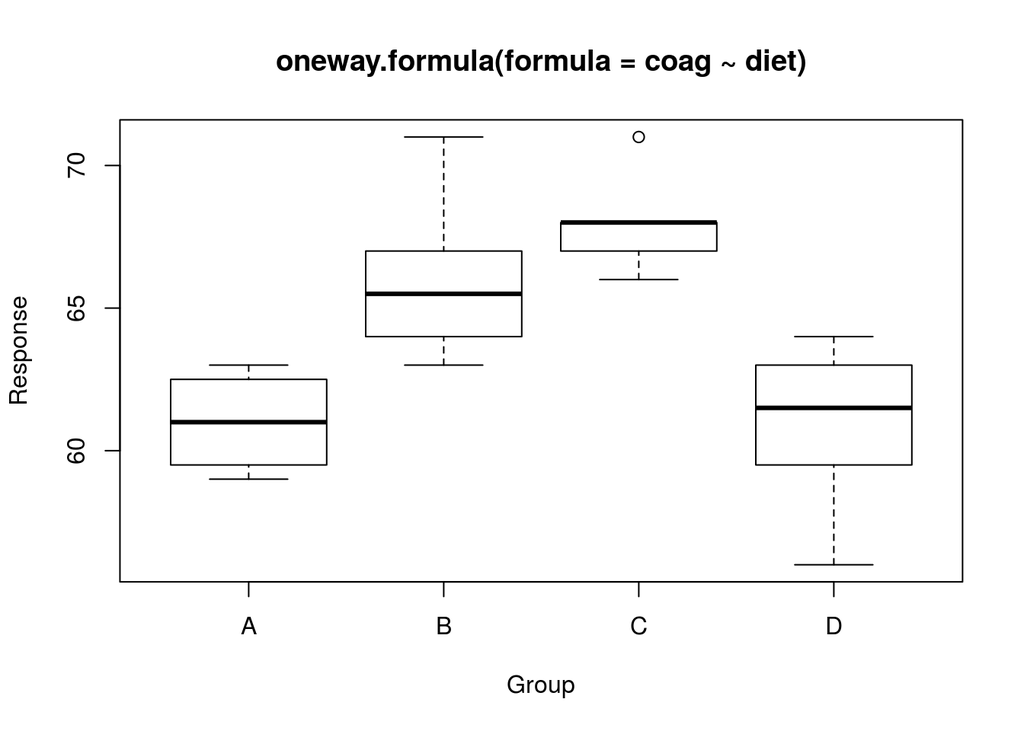

The example should illustrate all aspects of your code.